# Mestrado em Hemoterapia: Bioestatística

## Fundamentos de Inferência

## Introdução

> Um dos principais objetivos da Estatística é tirar conclusões a partir dos dados.

> Dados em geral consistem de uma amostra de elementos de uma população de interesse.

> O objetivo é usar a amostra e tirar conclusões sobre a população.

> Quão confiável será utilizar a informação obtida apenas de uma amostra para concluir algo sobre a população?

## Inferência Estatística

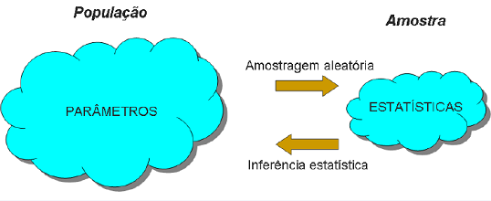

**Variável Aleatória**: Característica numérica do resultado de um experimento.

**População**: todos os elementos ou resultados de um problema que está sendo estudado.

**Amostra:** qualquer subconjunto da população que contém os elementos que podem ser observados e é onde as quantidades de interesse podem ser medidas.

## Inferência Estatística

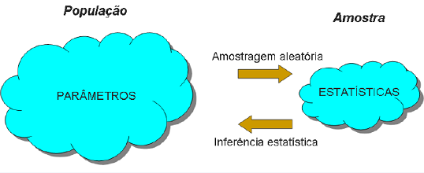

**Parâmetros**: Característica numérica (desconhecida) da distribuição dos elementos da população.

**Estimador/Estatística**: Função da amostra, construída com a finalidade de representar, ou estimar um parâmetro de interesse na população.

**Estimativa**: Valor numérico que um estimador assume para uma dada amostra.

## Estatística

Seja \(X_{1},...,X_{n}\) uma amostra, \(T=f(X_{1},...,X_{n})\) é uma estatística.

Exemplos:

- \(\bar{X}_{n}=\frac{1}{n}\sum_{i=1}^{n}X_{i}=\frac{1}{n}(X_{1}+...+X_{n})\): a média amostral é uma estatística.
- \(X_{(1)}=min\{X_{1},...,X_{n}\}\).
- \(X_{(n)}=max\{X_{1},...,X_{n}\}\).
- \(X_{(i)}\) é o i-ésimo valor da amostra ordenada.
- Note que uma estatística é uma função que em uma determinada amostra assume um valor específico (estimativa).

## Estatística

- Para que serve uma estatística? Para "estimar" os valores de uma distribuição, ou características de uma população.
- **População:**
  - \(\mbox{média}_{P}\).
  - \(\mbox{variância}_{P}\).
- **Amostra:**
  - \(\mbox{média}_{A} = \sum_{i=1}^{n}\frac{X_{i}}{n}\) "estima" a \(\mbox{média}_{P}\).
  - \(\mbox{variância}_{A} = \sum_{i=1}^{n}\frac{(X_{i}-\mbox{média}_{A})^{2}}{n}\) "estima" a \(\mbox{variância}_{P}\)

## Exemplo

Temos interesse em conhecer a média e variância das alturas dos brasileiros adultos. Sabemos que a distribuição das alturas pode ser representada por um modelo normal.

> Solução 1: Medir a altura de todos os brasileiros adultos.

> Solução 2: Selecionar de forma aleatória algumas pessoas (amostra), analisá-las e inferir propriedades para toda a população.

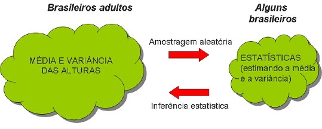

## Exemplo

Seja \(\theta\) a proporção de alunos na Unicamp que concorda com a presença da PM no campus.

- Inviável perguntar para todos os estudantes: coleta-se uma amostra.
- Planejamento amostral: obter uma amostra aleatória simples de tamanho \(n=100\) alunos, sem reposição.
- cada \(X_{i}\), \(i=1,...,100\), vai assumir o valor 1 se o aluno \(i\) concorda com presença da PM, e 0 se não.
- estatística: \(T=\frac{X_{1}+...+X_{100}}{100}\).
- uma vez que a coleta foi implementada, \(T\) assume um valor, por exemplo, 0.63, que será usado para estimar \(\theta\), ou seja, \(\hat\theta=0.63\).

## Parâmetro

- Cada quantidade de interesse (como \(\theta\) no exemplo anterior) é chamada de parâmetro da população.
- Para apresentar uma estimativa de um parâmetro (\(\hat\theta\)), devemos escolher uma estatística (\(T\)).
- Note que da maneira que o plano amostral foi executado (amostra aleatória simples), a estatística \(T\) é uma variável aleatória, visto que cada vez que executarmos o plano amostral poderemos obter resultados diversos.
- Portanto, a estatística \(T\) possui uma distribuição de probabilidade, chamada de **distribuição amostral** de T.

## Teorema Central do Limite

## Teorema Central do Limite (TCL)

**Resultado**

Para uma amostra aleatória simples \(X_{1},...,X_{n}\) coletada de uma população com média \(\mu\) e variância \(\sigma^{2}\), a distribuição amostral de \(\bar{X}_{n}\) aproxima-se de uma **distribuição Normal** de média \(\mu\) e variância \(\frac{\sigma^{2}}{n}\), quando \(n\) for suficientemente grande.

Definimos também:

\[Z=\frac{\bar{X}_{n}-\mu}{\sigma / \sqrt{n}} \sim N(0,1)\]

## Teorema do Limite Central

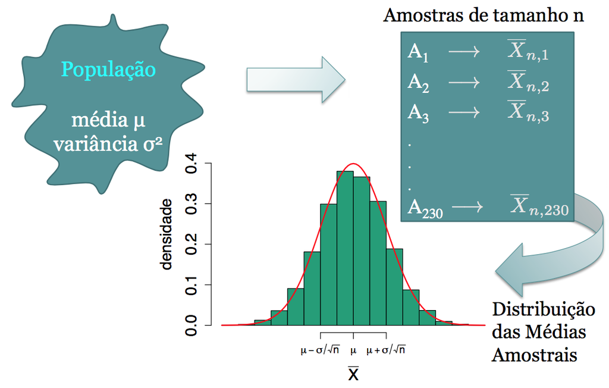

## Exemplo

\(X=\) resultado obtido no lançamento de um dado honesto.

| \(x\) | 1 | 2 | 3 | 4 | 5 | 6 |
| --- | --- | --- | --- | --- | --- | --- |
| \(p(x)=P(X=x)\) | \(\frac{1}{6}\) | \(\frac{1}{6}\) | \(\frac{1}{6}\) | \(\frac{1}{6}\) | \(\frac{1}{6}\) | \(\frac{1}{6}\) |

> \(E(X)=\frac{1}{6}\times(1+2+3+4+5+6)=\frac{21}{6}=3.5\)

## Exemplo

> O primeiro histograma a seguir mostra o resultado de 10000 repetições do seguinte experimento: observar o resultado do lançamento de 1 dado. Repare que é muito próximo de uma distribuição uniforme discreta (chance 1/6 para cada resultado).

> O segundo histograma mostra o resultado de 10000 repetições do seguinte experimento: observar a média do lançamento de 2 dados (equivalente a observar a média de 2 lançamentos de um dado).

> O último histograma mostra o resultado de 10000 repetições do seguinte experimento: observar a média do lançamento de 100 dados (equivalente a observar a média de 100 lançamentos de um dado).

## Exemplo

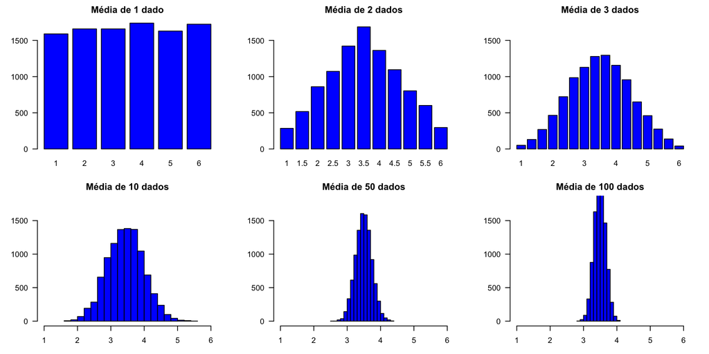

## Teorema do Limite Central (TLC)

Você pode verificar o comportamento de \(\bar{X}\) para vários tipos de distribuição de \(X\):

https://nishantsbi.shinyapps.io/CLT_Shiny

https://gallery.shinyapps.io/CLT_mean/

## Leituras

- [Ross](http://www.sciencedirect.com/science/article/pii/B9780123743886000077): capítulo 7.
- [OpenIntro](https://www.openintro.org/stat/textbook.php): seção 4.1.
- Magalhães: capítulo 7.

Slides produzidos pelos professores:

- Samara Kiihl
- Tatiana Benaglia
- Benilton Carvalho